# Analyzing Which Variables Influence Game Outcomes in a League of Legends Match

### Introduction

Riot Games created and released [League of Legends](https://www.leagueoflegends.com/en-us/) (LoL), sometimes known as League, a multiplayer online battle arena computer game in 2009. The creators of Riot were motivated to create a standalone game in the similar genre by the Warcraft III custom map Defense of the Ancients. League has been a free-to-play game since its inception in October 2009, and it earns money through the sale of customisable character skins. Both macOS and Microsoft Windows support the game.

In the game, there are two teams of five players each, and they engage in player-versus-player combat while defending and occupying their respective halves of the battlefield. The ten players each control a "champion," a figure with special abilities and a different playing style. Champions gain strength during a match by gaining experience points, earning gold, and investing in items to outwit the opposing team. In Summoner's Rift, the main game of League, a team wins by breaking through to the enemy base and destroying their "Nexus," a sizable structure within.

Riot Games provides a [REST API](https://developer.riotgames.com/apis) that gives developers access to information for use in creating our own software or websites. All League of Legends APIs are now version 4 (updated on March 19, 2020). Since this release, a minor version is no longer included in the API path. Riot games API can do the following Service status, Summoner details: name, level, profile icon, account ids, Match History and Match details and timelines by Summoner name, Someone’s current game info, if someone is in the game, Other information, check out the API documentation. For this project we will be using this api to collect the data needed.

Our objective in this tutorial is to organize the in-game data that has been provided, offer insightful information about which teams are more successful in terms of champion kills, herald kills, and tower kills, and analyze which variables are correlated with game outcome based on the available data.

### Data Collection

Throughout our program, we utilize a various amount of libraries, some of the important ones being: [requests](https://requests.readthedocs.io/en/latest/), [pandas](https://pandas.pydata.org/), [seaborn](https://seaborn.pydata.org/), and [statsmodel](https://www.statsmodels.org/stable/index.html).

Unfortunately, getting the match data from a player's id requires multiple requests from the API. First, we must get the summonerId of each player. The Riot API provides us with the player information from the highest rankings - Challenger, Grandmaster and Master.

To retrieve data from the API, an API Key is required from the Riot website. After we have authorization for accessing the API, we can retrieve the summonerId of each player utilizing the requests library.

```python
import requests
import os
import time
import warnings
warnings.filterwarnings("ignore")

summonerIds = []
API_KEY = os.getenv('API_KEY')

# Challenger League
CHAL_URL = "https://na1.api.riotgames.com/lol/league/v4/challengerleagues/by-queue/RANKED_SOLO_5x5"
chal_response = requests.get(CHAL_URL, headers={'X-Riot-Token': API_KEY})

# Get the summonerID for each player in the Challenger league
entries = chal_response.json()['entries']
for entry in entries:
    summonerIds.append(entry['summonerId'])

# Grandmaster League
GM_URL = "https://na1.api.riotgames.com/lol/league/v4/challengerleagues/by-queue/RANKED_SOLO_5x5"
gm_response = requests.get(GM_URL, headers={'X-Riot-Token': API_KEY})

# Get the summonerID for each player in the Grandmaster league
entries = gm_response.json()['entries']
for entry in entries:
    summonerIds.append(entry['summonerId'])

# Master League
M_URL = "https://na1.api.riotgames.com/lol/league/v4/challengerleagues/by-queue/RANKED_SOLO_5x5"
m_response = requests.get(M_URL, headers={'X-Riot-Token': API_KEY})

# Get the summonerID for each player in the Master league
entries = m_response.json()['entries']
for entry in entries:
    summonerIds.append(entry['summonerId'])
```

Then, if the puuids.txt file exists, we read each line of the file and put it there. If not, we obtain data through the Riot API. While doing this, however, we must employ sleep to make sure that we wait at least 2 minutes between each 100 requests. A basic API Key will only allow developers to make 100 requests every 2 minutes, so we must be careful not to reach the limit with these requests.

```python
puuids = []

# If the puuids.txt file exists, read each line of the file and store it in puuids
try:
    with open(r'./puuids.txt', 'r') as fp:
        for line in fp:
            puuids.append(line[:-1])
        print('Opened file puuids.txt')

# If file does not exist, get data from the Riot API
except IOError:
    SUMMONER_URL = "https://na1.api.riotgames.com/lol/summoner/v4/summoners/"
    for index, id in enumerate(summonerIds, 1):
        # For every 100 requests, wait at least 2 minutes
        if index % 100 == 0:
            time.sleep(130)

        response = requests.get(SUMMONER_URL + id, headers={'X-Riot-Token': API_KEY})
        summoner = response.json()
        puuids.append(summoner['puuid'])

    # Create a new file with the puuids
    with open(r'./puuids.txt', 'w+') as fp:
        for puuid in puuids:
            fp.write(f"{puuid}\n")
        print('Created new file puuids.txt')
```

```
Opened file puuids.txt
```

From here, we use set for matchIds to prevent storing duplicate matches. If the match ids.txt file already exists, we read each line and store it in matchIds; otherwise, we get data from the Riot API. Here, we also need to use sleep to make sure that we wait at least two minutes between every 100 requests.

```python
# Use set for matchIds as we do not want to store duplicate matches
matchIds = set()

# If the match_ids.txt file exists, read each line of the file and store it in matchIds
try:
    with open(r'./match_ids.txt', 'r') as fp:
        for line in fp:
            matchIds.add(line[:-1])
        print('Opened file match_ids.txt')

# If file does not exist, get data from the Riot API
except IOError:
    MATCHIDS_URL = lambda x : f"https://americas.api.riotgames.com/lol/match/v5/matches/by-puuid/{x}/ids?type=ranked&start=0&count=100"
    for index, puuid in enumerate(puuids, 1):
        # For every 100 requests, wait at least 2 minutes
        if index % 100 == 0:
            time.sleep(130)

        response = requests.get(MATCHIDS_URL(puuid), headers={'X-Riot-Token': API_KEY})
        matches = response.json()
        matchIds.update(matches)

    # Create a new file with the match_ids
    with open(r'./match_ids.txt', 'w+') as fp:
        for matchId in matchIds:
            fp.write(f"{matchId}\n")
        print('Created new file match_ids.txt')
```

```
Opened file match_ids.txt
```

So we get the first 10,000 matches and its variables when the game has finished like match id, champ kills, baron kills, drag kills, herald kills, tower kills, inhib kills, total gold, total dmg, win which we read the csv file and store each row as a dict in teams_data if the team data.csv file already exists. If it doesn't, the data is obtained from the Riot API.

```python
import csv

teams_data = []

# If the team_data.csv file exists, read the csv file and store each row as a dict in teams_data
try:
    with open(r'./team_data.csv', 'r') as fp:
        csvFile = csv.DictReader(fp)

        for line in csvFile:
            teams_data.append(dict(line))
        print('Opened file team_data.txt')

# If file does not exist, get data from Riot API
except IOError:
    MATCHDATA_URL = lambda x : f"https://americas.api.riotgames.com/lol/match/v5/matches/{x}"

    # Column names
    fieldnames = [
        'match_id',
        'team1_champ_kills',
        'team1_baron_kills',
        'team1_drag_kills',
        'team1_herald_kills',
        'team1_tower_kills',
        'team1_inhib_kills',
        'team1_total_gold',
        'team1_total_dmg',
        'team1_win',
        'team2_champ_kills',
        'team2_baron_kills',
        'team2_drag_kills',
        'team2_herald_kills',
        'team2_tower_kills',
        'team2_inhib_kills',
        'team2_total_gold',
        'team2_total_dmg',
        'team2_win'
        ]
    for index, matchId in enumerate(matchIds, 1):
        # Get only the first 10,000 matches
        if index == 10_000:
            break

        # For every 100 requests, wait at least 2 minutes
        if index % 100 == 0:
            time.sleep(130)

        response = requests.get(MATCHDATA_URL(matchId), headers={'X-Riot-Token': API_KEY})
        match_data = response.json()

        team_data = {}
        # Only get data if the 'info' field exists
        if 'info' in match_data:
            team_data['match_id'] = matchId

            # Get information from the 'teams' field in the 'info' field
            teams = match_data['info']['teams']
            team1 = teams[0]
            team_data['team1_champ_kills'] = team1['objectives']['champion']['kills']
            team_data['team1_baron_kills'] = team1['objectives']['baron']['kills']
            team_data['team1_drag_kills'] = team1['objectives']['dragon']['kills']
            team_data['team1_herald_kills'] = team1['objectives']['riftHerald']['kills']
            team_data['team1_tower_kills'] = team1['objectives']['tower']['kills']
            team_data['team1_inhib_kills'] = team1['objectives']['inhibitor']['kills']
            team_data['team1_win'] = 1 if team1['win'] else 0

            team2 = teams[1]
            team_data['team2_champ_kills'] = team2['objectives']['champion']['kills']
            team_data['team2_baron_kills'] = team2['objectives']['baron']['kills']
            team_data['team2_drag_kills'] = team2['objectives']['dragon']['kills']
            team_data['team2_herald_kills'] = team2['objectives']['riftHerald']['kills']
            team_data['team2_tower_kills'] = team2['objectives']['tower']['kills']
            team_data['team2_inhib_kills'] = team2['objectives']['inhibitor']['kills']
            team_data['team2_win'] = 1 if team2['win'] else 0

            team1_total_gold = 0
            team1_total_dmg = 0
            team2_total_gold = 0
            team2_total_dmg = 0
            # Go through each player from the match and add all of the totalDamageDealtToChampions and goldEarned for each team
            for p in match_data['info']['participants']:
                if p['teamId'] == 100:
                    team1_total_gold += p['goldEarned']
                    team1_total_dmg += p['totalDamageDealtToChampions']
                else:
                    team2_total_gold += p['goldEarned']
                    team2_total_dmg += p['totalDamageDealtToChampions']

            team_data['team1_total_gold'] = team1_total_gold
            team_data['team1_total_dmg'] = team1_total_dmg
            team_data['team2_total_gold'] = team2_total_gold
            team_data['team2_total_dmg'] = team2_total_dmg

            teams_data.append(team_data)

    # Create a new csv file with the team data
    with open(r'./team_data.csv', 'w+', newline='') as fp:
        writer = csv.DictWriter(fp, fieldnames=fieldnames)
        writer.writeheader()
        writer.writerows(teams_data)
        print('Created new file team_data.csv')
```

```
Opened file team_data.txt
```

Here, we will get the first 10,000 matches and its variables at 20 minutes of the game like match id, champ kills, baron kills, drag kills, herald kills, tower kills, inhib kills, total gold, total dmg, win which we read the csv file if the team_data_20.csv file already exists. If it doesn't, the data is obtained from the Riot API.

```python
from collections import defaultdict

# If the team_data_20.csv file exists, we do not need to get any data from the API
try:
    with open(r'./team_data_20.csv', 'r') as fp:
        print('Opened file team_data_20.txt')

# If file does not exist, get data from Riot API
except IOError:
    MATCHTIMELINE_URL = lambda x : f"https://americas.api.riotgames.com/lol/match/v5/matches/{x}/timeline"

    # Data gathered from start to MAX_TIME (20 minutes)
    MAX_TIME = 1_210_000

    # Column names
    fieldnames = [
        'match_id',
        'team1_champ_kills',
        'team1_baron_kills',
        'team1_drag_kills',
        'team1_herald_kills',
        'team1_tower_kills',
        'team1_inhib_kills',
        'team1_total_gold',
        'team1_total_dmg',
        'team2_champ_kills',
        'team2_baron_kills',
        'team2_drag_kills',
        'team2_herald_kills',
        'team2_tower_kills',
        'team2_inhib_kills',
        'team2_total_gold',
        'team2_total_dmg',
        ]

    # Participant IDs
    TEAM1_IDS = ["1", "2", "3", "4", "5"]
    TEAM2_IDS = ["6", "7", "8", "9", "10"]

    for index, matchId in enumerate(matchIds[99:1000], 1):
        # Get only the first 10,000 matches
        if index == 10_000:
            break

        # For every 100 requests, wait at least 2 minutes
        if index % 100 == 0:
            time.sleep(130)

        response = requests.get(MATCHTIMELINE_URL(matchId), headers={'X-Riot-Token': API_KEY})
        match_timeline = response.json()

        team_data = defaultdict(lambda: 0)
        # Only get data if the 'info' field exists
        if 'info' in match_timeline:
            team_data['match_id'] = matchId

            frames = match_timeline['info']['frames']
            lastFrame = {}
            # Go through each frame to get kill data
            for frame in frames:
                events = frame['events']
                timestamp = frame['timestamp']

                if timestamp > MAX_TIME:
                    break

                events = frame['events']
                for event in events:
                    if 'type' not in event:
                        continue

                    match event['type']:
                        case 'CHAMPION_KILL':
                            if event['killerId'] in range(1, 6):
                                team_data['team1_champ_kills'] += 1
                            elif event['killerId'] in range(6, 11):
                                team_data['team2_champ_kills'] += 1

                        case 'ELITE_MONSTER_KILL':
                            if event['killerTeamId'] == 100:
                                team_data[f"team1_{event['monsterType']}"] += 1
                            elif event['killerTeamId'] == 200:
                                team_data[f"team2_{event['monsterType']}"] += 1

                        case 'BUILDING_KILL':
                            if event['teamId'] == 200:
                                team_data[f"team1_{event['buildingType']}"] += 1
                            elif event['teamId'] == 100:
                                team_data[f"team2_{event['buildingType']}"] += 1

            # Rename dictionary key names to correct csv column names
            new_key_names = [
                ('team1_drag_kills', 'team1_DRAGON'),
                ('team1_herald_kills', 'team1_RIFTHERALD'),
                ('team1_baron_kills', 'team1_BARON_NASHOR'),
                ('team1_tower_kills', 'team1_TOWER_BUILDING'),
                ('team1_inhib_kills', 'team1_INHIBITOR_BUILDING'),
                ('team2_drag_kills', 'team2_DRAGON'),
                ('team2_baron_kills', 'team2_BARON_NASHOR'),
                ('team2_herald_kills', 'team2_RIFTHERALD'),
                ('team2_tower_kills', 'team2_TOWER_BUILDING'),
                ('team2_inhib_kills', 'team2_INHIBITOR_BUILDING')
                ]

            for new, old in new_key_names:
                team_data[new] = team_data.pop(old, 0)

            lastFrame = frame

            # Get the total gold for each team
            participants = lastFrame['participantFrames']
            for id in TEAM1_IDS:
                team_data['team1_total_gold'] += participants[id]['totalGold']

            for id in TEAM2_IDS:
                team_data['team2_total_gold'] += participants[id]['totalGold']

            teams_data.append(team_data)
    # Create a new csv file with the team data
    with open(r'./team_data_20.csv', 'w+', newline='') as fp:
        writer = csv.DictWriter(fp, fieldnames=fieldnames)
        writer.writeheader()
        writer.writerows(teams_data_20)
        print('Created new file team_data_20.csv')
```

```
Opened file team_data_20.txt
```

### Data Management

By creating the csv file we were able to obtain both team_data and team_data_20 and using the read_csv function from pandas and cleaning the table we get a table to perform our analysis on.

```python
import pandas as pd


df_td_20 = pd.read_csv('./team_data_20.csv')
df_td = pd.read_csv('./team_data.csv')

# Delete total_dmg columns
df = df_td_20.drop('team1_total_dmg', axis=1)
df = df.drop('team2_total_dmg', axis=1)

# Delete baron_kills columns
df = df.drop('team1_baron_kills', axis=1)
df = df.drop('team2_baron_kills', axis=1)

df = df.merge(df_td[['match_id', 'team1_win', 'team2_win']], on='match_id')
df = df.dropna()
df = df.drop_duplicates()

df.head()
```

|  | match_id | team1_champ_kills | team1_drag_kills | team1_herald_kills | team1_tower_kills | team1_inhib_kills | team1_total_gold | team2_champ_kills | team2_drag_kills | team2_herald_kills | team2_tower_kills | team2_inhib_kills | team2_total_gold | team1_win | team2_win |
| --- | --- | --- | --- | --- | --- | --- | --- | --- | --- | --- | --- | --- | --- | --- | --- |
| 0 | NA1_4447592729 | 9.0 | 2 | 0 | 3 | 0 | 36733 | 18.0 | 0 | 1 | 4 | 0 | 41741 | 0 | 1 |
| 2 | NA1_4452827587 | 16.0 | 0 | 0 | 2 | 0 | 40333 | 22.0 | 1 | 2 | 3 | 0 | 43092 | 0 | 1 |
| 4 | NA1_4477918900 | 21.0 | 3 | 0 | 3 | 0 | 43913 | 14.0 | 0 | 2 | 1 | 0 | 38587 | 1 | 0 |
| 6 | NA1_4482073494 | 14.0 | 0 | 2 | 3 | 0 | 39569 | 7.0 | 3 | 0 | 1 | 0 | 35610 | 0 | 1 |
| 8 | NA1_4457850765 | 7.0 | 0 | 0 | 0 | 0 | 32254 | 13.0 | 3 | 2 | 2 | 0 | 37259 | 0 | 1 |

In the above Team dataset, there are 15 columns. We have: Match ID Team Champion Kills (both teams) Team Herald Kills (both teams) Team Tower Kills (both teams) Team Inhibitor Kills (both teams) Team Total Golds (both teams) Team Wins (both teams) Each column's names ought to be self-explanatory. Important issues contain links to supplementary information if you want to learn more about a column in the context of the game.

### Graphing and Data Analysis

We'll utilize Seaborn to implement our graphs during this section.

##### Win Rate Based on Team

Here we will calculate the sum of each team's win and divide it by the total number of rows and then we will graph it based on the value given.

Equations: win rate = team total wins / total games

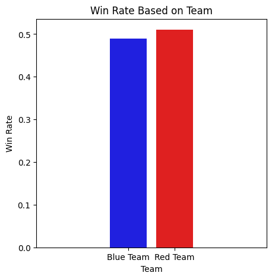

```python
import seaborn as sns
import matplotlib.pyplot as plt

df_wins = df[['team1_win','team2_win']].copy()

# Calculate the winrate for the blue and red team
# Team 1 is blue team, team 2 is red team
blue_winrate = df_wins['team1_win'].sum() / len(df_wins.index)
red_winrate = df_wins['team2_win'].sum() / len(df_wins.index)

x = ['Blue Team', 'Red Team']
y = [blue_winrate, red_winrate]

clrs = ['blue' if (x == 'Blue Team') else 'red' for x in x ]

fig, ax = plt.subplots(figsize=(5, 5))

sns.barplot(x=x, y=y, data=df_wins, palette=clrs)
ax.set(xlabel='Team', ylabel='Win Rate', title='Win Rate Based on Team')
ax.set_xbound(-2, 3)

plt.show()
```

Many players in the League of Legends community claim that the Red Team will have an advantage in games. From the data, it seems like the red team actually does has a slightly better chance of winning.

##### Win Rate Based on Kill Ratio

Here, we determine the kill ratios (team total kills/total kills among both teams) for both sides, add those kill ratios to a new column, and then count the number of games for each kill ratio. We will also count the number of wins for each kill ratio. With the total games and total wins, we can calculate the win ratio (total wins/total games) for each kill ratio.

```python
df_kills = df[['team1_champ_kills', 'team1_win', 'team2_champ_kills', 'team2_win']].copy()

# Calculate the kill ratio of team1 (team1 kills/total kills in game)
def team1_kr(row):
    total = row['team1_champ_kills'] + row['team2_champ_kills']
    return row['team1_champ_kills']/total

# Calculate the kill ratio of team2 (team2 kills/total kills in game)
def team2_kr(row):
    total = row['team1_champ_kills'] + row['team2_champ_kills']
    return row['team2_champ_kills']/total

# Create new columns with the kills ratios for each team
df_kills['team1_kill_ratio'] = df_kills.apply(team1_kr, axis=1)
df_kills['team2_kill_ratio'] = df_kills.apply(team2_kr, axis=1)

df_kills1 = df_kills[['team1_kill_ratio', 'team1_win']].copy()
df_kills2 = df_kills[['team2_kill_ratio', 'team2_win']].copy()

# Get the total number of matches for each kill ratio
team1_kd_count = df_kills['team1_kill_ratio'].value_counts()
team2_kd_count = df_kills['team2_kill_ratio'].value_counts()
kd_count = team1_kd_count.add(team2_kd_count, fill_value=0)

# Create new dataframe for kill ratios
df_kills = pd.DataFrame({
    'kill_ratio': kd_count.index,
    'total_games': kd_count,
    }).sort_values(by=['kill_ratio'])

df_kills1 = df_kills1.groupby('team1_kill_ratio')['team1_win'].sum()
df_kills2 = df_kills2.groupby('team2_kill_ratio')['team2_win'].sum()

df_kills['total_wins'] = df_kills1.add(df_kills2, fill_value=0)
df_kills['win_rate'] = df_kills.apply(lambda row: row['total_wins'] / row['total_games'], axis=1)
df_kills.head()
```

|  | kill_ratio | total_games | total_wins | win_rate |
| --- | --- | --- | --- | --- |
| 0.040000 | 0.040000 | 1.0 | 0.0 | 0.0 |
| 0.043478 | 0.043478 | 1.0 | 0.0 | 0.0 |
| 0.045455 | 0.045455 | 1.0 | 0.0 | 0.0 |
| 0.047619 | 0.047619 | 1.0 | 0.0 | 0.0 |
| 0.050000 | 0.050000 | 2.0 | 0.0 | 0.0 |

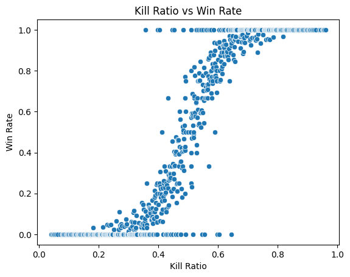

```python
ax = sns.scatterplot(data=df_kills, x='kill_ratio', y='win_rate')
ax.set(xlabel='Kill Ratio', ylabel='Win Rate', title='Kill Ratio vs Win Rate')
plt.show()
```

The correlation between win rate and kill ratio appears to be very clear. We can observe from the scatter graph that there is a positive relationship between the kill ratio and win rate; the higher the kill ratio, the more likely a team is to win. The shut down gold, which rewards players with more money for kills when the other side has more gold, also causes certain outliers in the scatter graph, which keeps the game exciting and produces unexpected turning points. The team that has more kills will typically have more gold and experience, and this will have a snowball effect where the winning team gains more kills since they have more gold and better items.

```python
import statsmodels.formula.api as sm

result = sm.ols(formula="win_rate ~ kill_ratio", data=df_kills).fit()
print(result.summary())
```

```
                            OLS Regression Results
==============================================================================
Dep. Variable:               win_rate   R-squared:                       0.816
Model:                            OLS   Adj. R-squared:                  0.816
Method:                 Least Squares   F-statistic:                     3444.
Date:                Fri, 16 Dec 2022   Prob (F-statistic):          9.08e-288
Time:                        23:49:05   Log-Likelihood:                 205.72
No. Observations:                 779   AIC:                            -407.4
Df Residuals:                     777   BIC:                            -398.1
Df Model:                           1
Covariance Type:            nonrobust
==============================================================================
                 coef    std err          t      P>|t|      [0.025      0.975]
------------------------------------------------------------------------------
Intercept     -0.3930      0.017    -23.658      0.000      -0.426      -0.360
kill_ratio     1.7861      0.030     58.685      0.000       1.726       1.846
==============================================================================
Omnibus:                       19.146   Durbin-Watson:                   1.042
Prob(Omnibus):                  0.000   Jarque-Bera (JB):               39.590
Skew:                           0.000   Prob(JB):                     2.53e-09
Kurtosis:                       4.104   Cond. No.                         5.75
==============================================================================

Notes:
[1] Standard Errors assume that the covariance matrix of the errors is correctly specified.
```

The OLS Regression results also support our claim. We can see that the P-Value is practically zero, which gives a very likely chance of rejecting the null hypothesis - that there is no relationship between the kill ratio and win rate.

##### Win Rate Based on Tower Kills

The tower kills for both teams will be grouped. For each tower kill value for both teams, we will obtain the overall number of matches and the total number of wins for each turret kill. Using these two values, we can calculate the winrate for each tower kill.

```python
df_tower1 = df[['team1_tower_kills', 'team1_win']].copy()
df_tower1 = df_tower1.groupby('team1_tower_kills')['team1_win'].sum().reset_index()

df_tower2 = df[['team2_tower_kills', 'team2_win']].copy()
df_tower2 = df_tower2.groupby('team2_tower_kills')['team2_win'].sum().reset_index()

# Get the total number of matches for each tower_kill value for each team
team1_tower_kills = df['team1_tower_kills'].value_counts()
team2_tower_kills = df['team2_tower_kills'].value_counts()
tower_kills_count = team1_tower_kills.add(team2_tower_kills, fill_value=0)

# Create new dataframe with the total number of matches for each tower_kill value
df_tower = pd.DataFrame({'tower_kills': tower_kills_count.index, 'total_games': tower_kills_count}).sort_values(by=['tower_kills'])
df_tower['total_wins'] = df_tower1['team1_win'].add(df_tower2['team2_win'], fill_value=0)
df_tower['win_rate'] = df_tower.apply(lambda row: row['total_wins'] / row['total_games'], axis=1)
df_tower.head()
```

|  | tower_kills | total_games | total_wins | win_rate |
| --- | --- | --- | --- | --- |
| 0 | 0 | 2548 | 177 | 0.069466 |
| 1 | 1 | 3194 | 646 | 0.202254 |
| 2 | 2 | 3552 | 1477 | 0.415822 |
| 3 | 3 | 3334 | 2138 | 0.641272 |
| 4 | 4 | 2175 | 1753 | 0.805977 |

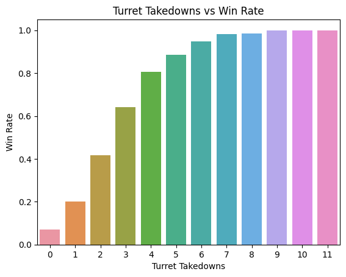

```python
ax = sns.barplot(data=df_tower, x='tower_kills', y='win_rate')
ax.set(xlabel='Turret Takedowns', ylabel='Win Rate', title='Turret Takedowns vs Win Rate')
plt.show()
```

The win rate seems to be rising along with the number of turret takedowns. This makes sense because taking down turrets awards gold to the team that did it. Additionally, it demonstrates the game's dominance because when champions or minions strike the turrets, the tower is damaged. Hitting the turrets demonstrates which team is presently in control of the game, which displays who is currently favoring winning.

```python
result = sm.ols(formula="win_rate ~ tower_kills", data=df_tower).fit()
print(result.summary())
```

```
                            OLS Regression Results
==============================================================================
Dep. Variable:               win_rate   R-squared:                       0.797
Model:                            OLS   Adj. R-squared:                  0.777
Method:                 Least Squares   F-statistic:                     39.26
Date:                Fri, 16 Dec 2022   Prob (F-statistic):           9.31e-05
Time:                        23:49:13   Log-Likelihood:                 6.1368
No. Observations:                  12   AIC:                            -8.274
Df Residuals:                      10   BIC:                            -7.304
Df Model:                           1
Covariance Type:            nonrobust
===============================================================================
                  coef    std err          t      P>|t|      [0.025      0.975]
-------------------------------------------------------------------------------
Intercept       0.2868      0.086      3.322      0.008       0.094       0.479
tower_kills     0.0833      0.013      6.266      0.000       0.054       0.113
==============================================================================
Omnibus:                        3.245   Durbin-Watson:                   0.294
Prob(Omnibus):                  0.197   Jarque-Bera (JB):                1.108
Skew:                          -0.156   Prob(JB):                        0.575
Kurtosis:                       1.545   Cond. No.                         12.4
==============================================================================

Notes:
[1] Standard Errors assume that the covariance matrix of the errors is correctly specified.
```

The OLS Regression results for tower kills vs win rate also show that there is a strong relationship between the two. We can see that the P-value is very low, increasing the chances of rejecting the null hypothesis.

##### Win Rate Based on Dragon Kills

Dragons kills give teams benefits that make them stronger. The more dragon kills a team has, the more likely it is that they should win. First, the total number of games for each drag kill value for each team is obtained. The number of wins for each drag kill is also obtained. Using these values, we can calculate the win rate for each dragon kill.

```python
df_drag1 = df[['team1_drag_kills', 'team1_win']].copy()
df_drag1 = df_drag1.groupby('team1_drag_kills')['team1_win'].sum().reset_index()

df_drag2 = df[['team2_drag_kills', 'team2_win']].copy()
df_drag2 = df_drag2.groupby('team2_drag_kills')['team2_win'].sum().reset_index()

# Get the total number of matches for each drag_kill value for each team
team1_drag_kills = df['team1_drag_kills'].value_counts()
team2_drag_kills = df['team2_drag_kills'].value_counts()
drag_kills_count = team1_drag_kills.add(team2_drag_kills, fill_value=0)

# Create new dataframe with the total number of matches for each drag_kill value
df_drag = pd.DataFrame({'drag_kills': drag_kills_count.index, 'total_games': drag_kills_count}).sort_values(by=['drag_kills'])
df_drag['total_wins'] = df_drag1['team1_win'].add(df_drag2['team2_win'], fill_value=0)
df_drag['win_rate'] = df_drag.apply(lambda row: row['total_wins'] / row['total_games'], axis=1)
df_drag.head()
```

|  | drag_kills | total_games | total_wins | win_rate |
| --- | --- | --- | --- | --- |
| 0 | 0 | 5654 | 1033 | 0.182703 |
| 1 | 1 | 6358 | 3310 | 0.520604 |
| 2 | 2 | 4574 | 3544 | 0.774814 |
| 3 | 3 | 1026 | 919 | 0.895712 |

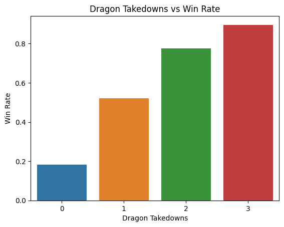

```python
ax = sns.barplot(data=df_drag, x='drag_kills', y='win_rate')
ax.set(xlabel='Dragon Takedowns', ylabel='Win Rate', title='Dragon Takedowns vs Win Rate')
plt.show()
```

The number of dragon takedowns appears to be increasing along with the win rate. This makes sense because killing dragons grants the team gold and certain benefits. The fact that teams with the advantage have a priority on whether they seize the dragon and the losing team must compete at a disadvantage further emphasizes the game's dominance. Taking the dragon reveals which team is currently in charge of the match, revealing who is currently in favor for victory.

```python
result = sm.ols(formula="win_rate ~ drag_kills", data=df_drag).fit()
print(result.summary())
```

```
                            OLS Regression Results
==============================================================================
Dep. Variable:               win_rate   R-squared:                       0.960
Model:                            OLS   Adj. R-squared:                  0.940
Method:                 Least Squares   F-statistic:                     48.15
Date:                Fri, 16 Dec 2022   Prob (F-statistic):             0.0201
Time:                        23:49:21   Log-Likelihood:                 5.9600
No. Observations:                   4   AIC:                            -7.920
Df Residuals:                       2   BIC:                            -9.147
Df Model:                           1
Covariance Type:            nonrobust
==============================================================================
                 coef    std err          t      P>|t|      [0.025      0.975]
------------------------------------------------------------------------------
Intercept      0.2345      0.065      3.634      0.068      -0.043       0.512
drag_kills     0.2393      0.034      6.939      0.020       0.091       0.388
==============================================================================
Omnibus:                          nan   Durbin-Watson:                   2.014
Prob(Omnibus):                    nan   Jarque-Bera (JB):                0.640
Skew:                           0.025   Prob(JB):                        0.726
Kurtosis:                       1.041   Cond. No.                         3.76
==============================================================================

Notes:
[1] Standard Errors assume that the covariance matrix of the errors is correctly specified.
```

The OLS Regression Results support our claim that more dragon kills will result in a higher chance of winning. Although the P-value is a little higher, it is still quite low (less than 0.1), and so the probability of rejecting the null hypothesis is still high.

##### Win Rate Based on Herald Kills

Just like dragon kills, herald kills make the team strong with more gold and other benefits. The total number of matches for each herald kill value for each side is obtained. We then get the total number of wins for each number of herald takedowns. With these values, we can calculate the winrate.

```python
df_herald1 = df[['team1_herald_kills', 'team1_win']].copy()
df_herald1 = df_herald1.groupby('team1_herald_kills')['team1_win'].sum().reset_index()

df_herald2 = df[['team2_herald_kills', 'team2_win']].copy()
df_herald2 = df_herald2.groupby('team2_herald_kills')['team2_win'].sum().reset_index()

# Get the total number of matches for each herald_kill value for each team
team1_herald_kills = df['team1_herald_kills'].value_counts()
team2_herald_kills = df['team2_herald_kills'].value_counts()
herald_kills_count = team1_herald_kills.add(team2_herald_kills, fill_value=0)

# Create new dataframe with the total number of matches for each herald_kill value
df_herald = pd.DataFrame({'herald_kills': herald_kills_count.index, 'total_games': herald_kills_count}).sort_values(by=['herald_kills'])
df_herald['total_wins'] = df_herald1['team1_win'].add(df_herald2['team2_win'], fill_value=0)
df_herald['win_rate'] = df_herald.apply(lambda row: row['total_wins'] / row['total_games'], axis=1)
df_herald.head()
```

|  | herald_kills | total_games | total_wins | win_rate |
| --- | --- | --- | --- | --- |
| 0 | 0 | 6314 | 1834 | 0.290466 |
| 1 | 1 | 6965 | 3801 | 0.545729 |
| 2 | 2 | 4333 | 3171 | 0.731826 |

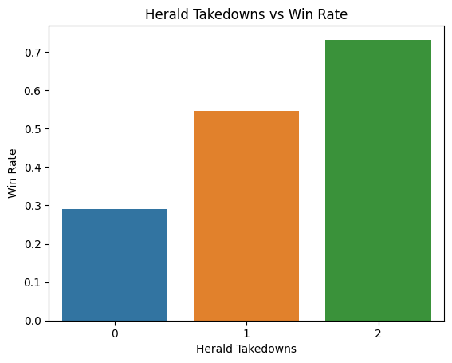

```python
ax = sns.barplot(data=df_herald, x='herald_kills', y='win_rate')
ax.set(xlabel='Herald Takedowns', ylabel='Win Rate', title='Herald Takedowns vs Win Rate')
plt.show()
```

The number of herald takedowns appears to be increasing along with the win rate. This makes sense because taking herald down awards gold to the team that did it. The fact that teams with the advantage have a priority on whether they seize the herald and the losing team must compete at a disadvantage further emphasizes the game's dominance. Taking the herald reveals which team is currently in charge of the match, revealing who is currently in favor for victory.

```python
result = sm.ols(formula="win_rate ~ herald_kills", data=df_herald).fit()
print(result.summary())
```

```
                            OLS Regression Results
==============================================================================
Dep. Variable:               win_rate   R-squared:                       0.992
Model:                            OLS   Adj. R-squared:                  0.984
Method:                 Least Squares   F-statistic:                     122.2
Date:                Fri, 16 Dec 2022   Prob (F-statistic):             0.0574
Time:                        23:49:26   Log-Likelihood:                 8.0925
No. Observations:                   3   AIC:                            -12.18
Df Residuals:                       1   BIC:                            -13.99
Df Model:                           1
Covariance Type:            nonrobust
================================================================================
                   coef    std err          t      P>|t|      [0.025      0.975]
--------------------------------------------------------------------------------
Intercept        0.3020      0.026     11.716      0.054      -0.026       0.630
herald_kills     0.2207      0.020     11.052      0.057      -0.033       0.474
==============================================================================
Omnibus:                          nan   Durbin-Watson:                   3.000
Prob(Omnibus):                    nan   Jarque-Bera (JB):                0.531
Skew:                           0.707   Prob(JB):                        0.767
Kurtosis:                       1.500   Cond. No.                         2.92
==============================================================================

Notes:
[1] Standard Errors assume that the covariance matrix of the errors is correctly specified.
```

We can see from the OLS Regression Results that the P-values are around 0.05. Although it is not zero, a low P-value indicates that there is a high chance of rejecting the null hypothesis, which means that there is likely a chance that herald kills result in wins.

##### Win Rate Based on Gold Ratio

The biggest factor in determining team strength is gold. When a team has gold, they are able to buy items that make them stronger. Here, we will calculate the gold ratio (team gold/total gold between both teams). We will have to bin the gold values into 50 ranges. For each bin, we will calculate the total number of games that have gold ratios in the bins range, the total number of wins, and finally the win rate based on the previous two values.

```python
df_gold = df[['team1_total_gold', 'team1_win', 'team2_total_gold', 'team2_win']].copy()

# Calculate the gold ratio of team1 (team1 gold/total gold in game)
def team1_gold(row):
    total = row['team1_total_gold'] + row['team2_total_gold']
    return row['team1_total_gold']/total

# Calculate the kill ratio of team2 (team2 gold/total gold in game)
def team2_gold(row):
    total = row['team1_total_gold'] + row['team2_total_gold']
    return row['team2_total_gold']/total

# Create new columns with the gold ratios for each team
df_gold['team1_gold_ratio'] = df_gold.apply(team1_gold, axis=1)
df_gold['team2_gold_ratio'] = df_gold.apply(team2_gold, axis=1)

df_gold1 = df_gold[['team1_gold_ratio', 'team1_win']].copy()
df_gold2 = df_gold[['team2_gold_ratio', 'team2_win']].copy()

# Get the total number of matches for each gold ratio
team1_gold_count = df_gold['team1_gold_ratio'].value_counts()
team2_gold_count = df_gold['team2_gold_ratio'].value_counts()
gold_count = team1_gold_count.add(team2_gold_count, fill_value=0)

# Create new dataframe for gold ratios
df_gold = pd.DataFrame({
    'gold_ratio': gold_count.index,
    'total_games': gold_count,
    }).sort_values(by=['gold_ratio'])

df_gold1 = df_gold1.groupby('team1_gold_ratio')['team1_win'].sum()
df_gold2 = df_gold2.groupby('team2_gold_ratio')['team2_win'].sum()

df_gold['total_wins'] = df_gold1.add(df_gold2, fill_value=0)
# Make a copy for future use
df_gold['bins'] = pd.cut(df_gold['gold_ratio'], 50)
df_reg = df_gold[['gold_ratio', 'bins']].copy().reset_index()
df_gold = df_gold.groupby(['bins'], as_index=False)[['total_games', 'total_wins']].sum()
df_gold['win_rate'] = df_gold.apply(lambda row: row['total_wins'] / row['total_games'], axis=1)
df_gold.head()
```

|  | bins | total_games | total_wins | win_rate |
| --- | --- | --- | --- | --- |
| 0 | (0.32, 0.327] | 1.0 | 0.0 | 0.0 |
| 1 | (0.327, 0.334] | 1.0 | 0.0 | 0.0 |
| 2 | (0.334, 0.342] | 6.0 | 0.0 | 0.0 |
| 3 | (0.342, 0.349] | 7.0 | 0.0 | 0.0 |
| 4 | (0.349, 0.356] | 12.0 | 0.0 | 0.0 |

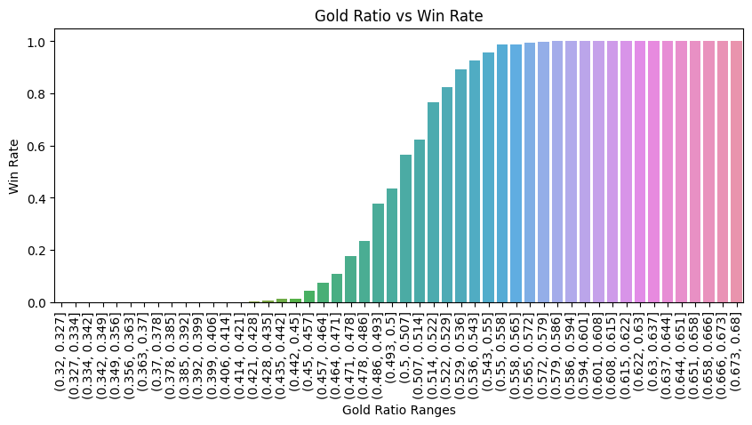

```python
fig, ax = plt.subplots(figsize=(10, 4))

ax = sns.barplot(data=df_gold, x='bins', y='win_rate')
ax.set(xlabel='Gold Ratio Ranges', ylabel='Win Rate', title='Gold Ratio vs Win Rate')

# Rotate x labels to make them readable
labels = ax.get_xticklabels()
ax.set_xticklabels(labels, rotation=90)

plt.show()
```

Our bargraph clearly shows a positive correlation between the gold ratio and win rate. We can make another plot to get a better look at the shape of the graph.

```python
df_reg = df_reg.drop('index', axis=1)
# Get the winrate for the bin that the gold ratio is contained in
df_reg['win_rate'] = df_reg.apply(lambda row: df_gold[df_gold['bins'] == row['bins']].iloc[[0]].squeeze()['win_rate'], axis=1)
df_reg = df_reg.drop('bins', axis=1)
df_reg.head()
```

|  | gold_ratio | win_rate |
| --- | --- | --- |
| 0 | 0.320056 | 0.0 |
| 1 | 0.330085 | 0.0 |
| 2 | 0.339160 | 0.0 |
| 3 | 0.340540 | 0.0 |
| 4 | 0.340737 | 0.0 |

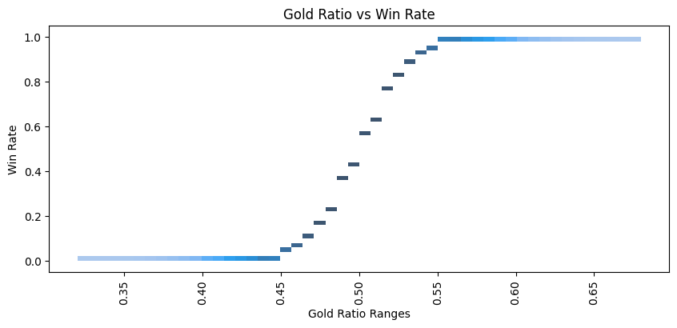

```python
fig, ax = plt.subplots(figsize=(10, 4))
ax = sns.histplot(data=df_reg, x='gold_ratio', y='win_rate', bins=50)
ax.set(xlabel='Gold Ratio Ranges', ylabel='Win Rate', title='Gold Ratio vs Win Rate')

# Rotate x labels to make them readable
labels = ax.get_xticklabels()
ax.set_xticklabels(labels, rotation=90)

plt.show()
```

The win rate rises along with the gold ratio. There appear to be several strong relationships. One of the key explanations is that the players will have better equipment if the team has more gold. Items and levels are among the most crucial winning variables in MOBAs due to the way they operate. The gold ratio identifies the team in charge and the teams with a chance of winning.

```python
result = sm.ols(formula="win_rate ~ gold_ratio", data=df_reg).fit()
print(result.summary())
```

```
                            OLS Regression Results
==============================================================================
Dep. Variable:               win_rate   R-squared:                       0.881
Model:                            OLS   Adj. R-squared:                  0.881
Method:                 Least Squares   F-statistic:                 1.298e+05
Date:                Fri, 16 Dec 2022   Prob (F-statistic):               0.00
Time:                        23:49:55   Log-Likelihood:                 10313.
No. Observations:               17608   AIC:                        -2.062e+04
Df Residuals:                   17606   BIC:                        -2.061e+04
Df Model:                           1
Covariance Type:            nonrobust
==============================================================================
                 coef    std err          t      P>|t|      [0.025      0.975]
------------------------------------------------------------------------------
Intercept     -2.9643      0.010   -306.549      0.000      -2.983      -2.945
gold_ratio     6.9285      0.019    360.248      0.000       6.891       6.966
==============================================================================
Omnibus:                       65.244   Durbin-Watson:                   0.000
Prob(Omnibus):                  0.000   Jarque-Bera (JB):               88.429
Skew:                          -0.000   Prob(JB):                     6.28e-20
Kurtosis:                       3.347   Cond. No.                         23.7
==============================================================================

Notes:
[1] Standard Errors assume that the covariance matrix of the errors is correctly specified.
```

Our P-values in our OLS Regression Result shows is zero, which supports our claim of our gold ratio having an effect on win rate.

#### Conclusion

From our analysis, we have shown that there are many variables that can increase the likeliness of winning a game. Objective kills, gold ratios, and kill ratios have all shown, from our analysis, an increase in win rate as those variables increase.

We believe that our data analysis and use of the datasets we gathered through our own research were successful. Undoubtedly, there are still many more datasets, such as bronze, silver, and gold data, to be found. Dataset based on champion masteries, victory rates, competition information, etc. While it may certainly be examined more, for this project we only focused on challengers, grand masters, and masters. Only the basic dataset were covered in this tutorial and anyone can further explore more if they wanted to and I think they should because it definitely is one of the interesting dataset.